# McKinsey Giviniostat gsea update

Harrison

6/3/2020

## **Background**

This report is for Drs. McKinsey (senior author) and Travers (first author) paper “HDAC Inhibition Reverses Preexisting Diastolic Dysfunction and Blocks Covert Extracellular Matrix Remodeling.”

Overview: Reviewers want a volcano plot for figure 5B instead of the plot which the analyst has originally plotted as FDR by NES (normalized enrichment score). Each dot is a ontology tested for enrichment using GSEA.

There are 3 plots as there are 3 pairwise comparisons conducted. Each plot visualizes the NES scores by -log10(Nominal P-values.)

GSEA cannot adequately resolve the smallest P values and some genesets without a value are considered < .00005. This is due to the memory limitations that GSEA has when performing calculations on large datasets.

## **Methods**

RNA-seq analysis was performed on a total of 12 biological replicates split into 3 conditions. The count data was aligned to the mm10 reference genome with HISAT2. The abundances per sample were quantified with cufflinks and normalized with cuffnorm. The resulting data was then FPKM normalized. Each of the 4 replicates per condition were then averaged and formatted as a GCT file to compare each condition using a single column for one group and another single column for a different group.

Each of the 3 comparisons were then inputted into the command line GSEA program separately to search for enrichment among a cohort of gene ontology genesets. The 3302 genesets were used and are among the ‘C2 v5.1’ curated genesets which include genesets from the Kegg, Biocarta, Reactome and PID databases. Enrichment ranking was calculated using the log 2 fold-change results for each comparison.

Identification of genesets of interest was performed via a keyword search containing Mesenchymal, Invasive, and Inflammatory. Genesets of interest were identified with keyword representation in the broad institutes annotations and identified in each GSEA report.

Volcano plots were used to visualize the genesets of interest in each comparison. The volcano plots were created using the -log10(Nominal Pvalue) by the NES scores to allow for better visualization of significant genesets of interest.

An FDR < .05 was used due to the small sample size as suggested by GSEA. 2 by 2 tables were created in order to quickly identify the quantity of genesets of interest that are either significant or not. Fishers Exact test was used to calculate P-values of these comparisons to indicate whether the genesets of interested are significantly represented.

The following is a list of the total parameters used with GSEA :

```
GSEA                 : GSEA2-3.0 beta
Collape              : false
mode                 : Max_prove
norm                 : meandiv
nperm                : 20000
permute              : gene_set
rnd_type             : no_balance
schoring_scheme      : weighted
metric               : log2_Ratio_of_Classe
sort                 : real
order                : descending
include_only_symbols : true
make_sets            : true
median               : false
num                  : 100
plot_top_x           : 20
set_max              : 500
set_min              : 15
```

### **Comparison: DOCA vs Sham**

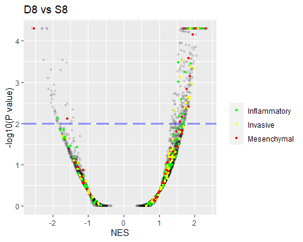

#### **All genesets in comparison**

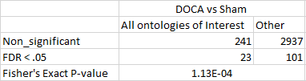

#### **Enriched in DOCA**

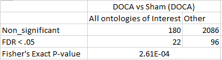

#### **Enriched in Sham**

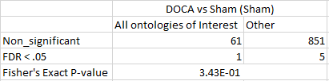

### **Comparison: ITF vs DOCA**

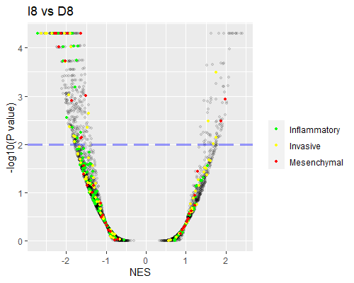

#### **Enriched in both ITF and DOCA**

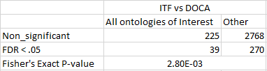

#### **Enriched in ITF**

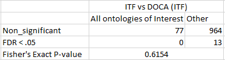

#### **Enriched in DOCA**

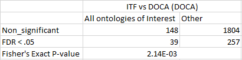

### **Comparison: ITF vs Sham**

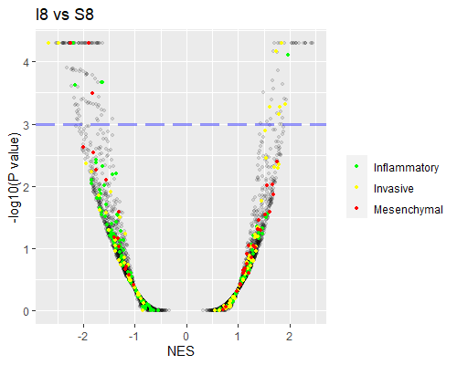

#### **Enriched in both ITF and Sham**

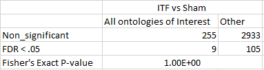

#### **Enriched in ITF**

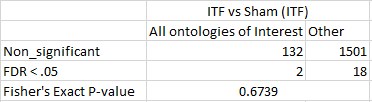

#### **Enriched in Sham**

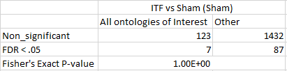